# Machine-Learning-vol.03-重回帰分析

## 3.1 今回のストーリー

重回帰分析とは､**複数の説明変数を利用した回帰分析**のことです｡単回帰分析ではひとつの説明変数のみを予測に利用していましたので､重回帰は**単回帰の拡張版**と考えることができます｡下図を見てもらうと､よりはっきりと実感が掴めるかと思います｡

同じ線形回帰で考えれば､単回帰分析では**2次元の平面内で直線を用いて回帰を行う**のに対し､説明変数が2つの重回帰分析では**3次元の空間内で平面を用いて回帰を行う**ようになります｡また､重回帰分析のときの回帰係数を**偏回帰係数**と呼びます｡もちろん､説明変数はもっと増すやこともできるので､4次元や5次元の空間内で回帰を行うこともあります｡ちなみに､高次元で直線や平面にあたるものは**超平面**と呼ばれます｡

[figure not shown]

### 分析ストーリー: 住宅価格の相場予測

[figure not shown]

> 米ボストンに､とある**不動産仲介の会社**がありました｡現在この会社は､自社サイトのトップページに**最新のお買い得物件を表示する機能**を追加することを検討しています｡この機能を自動化できれば､**自社サイトへの人の流入が増える**と考えたのです｡そして､そのためには**各住宅の相場価格**を回帰分析によって見積もることが必要になりました｡例えば､相場価格を算出することができれば､実際価格との比を取って､**割高度**を求めることができます｡**この値が1より大きいほどその物件は割高で､1より小さいほど割安**という意味の評価指標になります｡この会社は､自社に貯まっていたボストン市の各区画の住宅価格データを利用して､このシステムを構築することにしました｡

### Bostonデータセット

#### sklearn.datasets

今回は､scikit-learnに収録されている**Boston市郊外の住宅価格データセット**を利用します｡scikit-learnには､手元に分析できるデータがない人でも機械学習を試せるよう､**サンプルとなる小規模なデータセットが多数収録されています**｡**sklearn.datasets**からアクセスでき､住宅価格予測の他にも**乳がんの判定**､**アヤメの花の品種分類**､**手書き数字の画像分類**などのデータが収録されています｡

#### データの概観

Bostonデータセットは､**住宅価格を重回帰分析で予測するためのデータセット**です｡ボストン郊外居住区画ごとに**犯罪件数**や､**空気汚染の度合い**､あるいは住民人数における**肉体労働者の割合**などの**13種類**の説明変数と､目的変数である**住宅価格の中央値**が記されています｡こちらのデータは､1978年にHarrisonとRubinfeldによって調査がなされたものです｡サンプルとなる区画数が**506区画**と非常に少数なので､重回帰分析の練習のためのタスクとして利用されています｡

[figure not shown]

出典: [UCI Machine Learning Repository "Housing"](http://lib.stat.cmu.edu/datasets/boston)

```python
# ライブラリのインポート
import pandas as pd
import numpy as np
import matplotlib.pyplot as plt
% matplotlib inline
```

```python
# データセットを読み込み
from sklearn.datasets import load_boston # bostonデータを格納したクラス
boston = load_boston()                   # インスタンスを生成
```

### describeの確認

収録されているデータの詳細（describe）は**boston.DESCR**から確認することができます｡ここで､**データに関する基本的な情報**を確認することができます｡特に､以下に示すような情報をチェックすることが重要です｡

- 出典はどこか？
- 目的変数は何か？
- 説明変数は何か？
- サンプル数はいくつか？
- 欠損値はどれだけあるか？

```python
# データの詳細を出力
print(boston.DESCR)
```

```
Boston House Prices dataset
===========================

Notes
------
Data Set Characteristics:

    :Number of Instances: 506

    :Number of Attributes: 13 numeric/categorical predictive

    :Median Value (attribute 14) is usually the target

    :Attribute Information (in order):
        - CRIM     per capita crime rate by town
        - ZN       proportion of residential land zoned for lots over 25,000 sq.ft.
        - INDUS    proportion of non-retail business acres per town
        - CHAS     Charles River dummy variable (= 1 if tract bounds river; 0 otherwise)
        - NOX      nitric oxides concentration (parts per 10 million)
        - RM       average number of rooms per dwelling
        - AGE      proportion of owner-occupied units built prior to 1940
        - DIS      weighted distances to five Boston employment centres
        - RAD      index of accessibility to radial highways
        - TAX      full-value property-tax rate per $10,000
        - PTRATIO  pupil-teacher ratio by town
        - B        1000(Bk - 0.63)^2 where Bk is the proportion of blacks by town
        - LSTAT    % lower status of the population
        - MEDV     Median value of owner-occupied homes in $1000's

    :Missing Attribute Values: None

    :Creator: Harrison, D. and Rubinfeld, D.L.

This is a copy of UCI ML housing dataset.
http://archive.ics.uci.edu/ml/datasets/Housing


This dataset was taken from the StatLib library which is maintained at Carnegie Mellon University.

The Boston house-price data of Harrison, D. and Rubinfeld, D.L. 'Hedonic
prices and the demand for clean air', J. Environ. Economics & Management,
vol.5, 81-102, 1978.   Used in Belsley, Kuh & Welsch, 'Regression diagnostics
...', Wiley, 1980.   N.B. Various transformations are used in the table on
pages 244-261 of the latter.

The Boston house-price data has been used in many machine learning papers that address regression
problems.

**References**

   - Belsley, Kuh & Welsch, 'Regression diagnostics: Identifying Influential Data and Sources of Collinearity', Wiley, 1980. 244-261.
   - Quinlan,R. (1993). Combining Instance-Based and Model-Based Learning. In Proceedings on the Tenth International Conference of Machine Learning, 236-243, University of Massachusetts, Amherst. Morgan Kaufmann.
   - many more! (see http://archive.ics.uci.edu/ml/datasets/Housing)
```

また､英語では読みづらいという方向けに､**日本語訳**を用意しました｡参考までにご覧ください｡

| 特徴量 | 説明 |
| --- | --- |
| CRIM | 人口あたりの犯罪発生率 (%) |
| ZN | 25,000平方フィート以上の住居区画の占める割合(%) |
| INDUS | 小売業以外の商業施設が占める面積の割合(%) |
| CHAS | チャールズ川に関するダミー変数 (1: 川の周辺, 0: それ以外) |
| NOX | 空気汚染の指標としてのNOxの濃度 (単位: pphm) |
| RM | 住居の平均部屋数（単位: 部屋） |
| AGE | 1940 年より前に建てられた物件の割合（単位: %） |
| DIS | 5 つのボストン市の雇用施設からの､重み付けされた距離 |
| RAD | 環状高速道路へのアクセスしやすさ |
| TAX | $10,000 ドルあたりの不動産税率の総計 |
| PTRATIO | 町毎の児童と教師の比率 (単位: %) |
| B | 町毎の黒人 (Bk) の比率を次の式で表したもの。1000(Bk – 0.63)^2 |
| LSTAT | 給与の低い､下位1/3の職業に従事する人口の割合 (単位: %) |
| MEDV | 住宅価格の中央値（単位: 千ドル） |

### 含まれている特徴量の確認

続いて､データの中身を観察していきます｡まず､**データにどんな特徴量が含まれているのか**を調べてみましょう｡各特徴量の名称は､**boston.feature_names**にリストの形で収録されています｡

```python
# どんな説明変数があるのかを確認
# 項目名がbostonのfeature_namesに格納されている
columns = boston.feature_names
columns
```

```
array(['CRIM', 'ZN', 'INDUS', 'CHAS', 'NOX', 'RM', 'AGE', 'DIS', 'RAD',
       'TAX', 'PTRATIO', 'B', 'LSTAT'], dtype='<U7')
```

### 変数の確認

**説明変数**と**目的変数**を出力して確認してみましょう｡それぞれ**boston.data**と**boston.target**に格納されています｡

```python
# 説明変数を確認
boston.data
```

```
array([[6.3200e-03, 1.8000e+01, 2.3100e+00, ..., 1.5300e+01, 3.9690e+02,
        4.9800e+00],
       [2.7310e-02, 0.0000e+00, 7.0700e+00, ..., 1.7800e+01, 3.9690e+02,
        9.1400e+00],
       [2.7290e-02, 0.0000e+00, 7.0700e+00, ..., 1.7800e+01, 3.9283e+02,
        4.0300e+00],
       ...,
       [6.0760e-02, 0.0000e+00, 1.1930e+01, ..., 2.1000e+01, 3.9690e+02,
        5.6400e+00],
       [1.0959e-01, 0.0000e+00, 1.1930e+01, ..., 2.1000e+01, 3.9345e+02,
        6.4800e+00],
       [4.7410e-02, 0.0000e+00, 1.1930e+01, ..., 2.1000e+01, 3.9690e+02,
        7.8800e+00]])
```

```python
# 目的変数を確認
# 住宅価格の中央値MEDV
# 数が多いので､初めの50個のみを出力
boston.target[:50]
```

```
array([24. , 21.6, 34.7, 33.4, 36.2, 28.7, 22.9, 27.1, 16.5, 18.9, 15. ,
       18.9, 21.7, 20.4, 18.2, 19.9, 23.1, 17.5, 20.2, 18.2, 13.6, 19.6,
       15.2, 14.5, 15.6, 13.9, 16.6, 14.8, 18.4, 21. , 12.7, 14.5, 13.2,
       13.1, 13.5, 18.9, 20. , 21. , 24.7, 30.8, 34.9, 26.6, 25.3, 24.7,
       21.2, 19.3, 20. , 16.6, 14.4, 19.4])
```

## 3.2 データの観察

ここから､データの中身を詳細に観察していきます｡

まずは､pandasのDataFrameを用いてデータの整形を行いましょう｡

```python
# Pandasのデータフレームに変換
# (変数のarrya, 変数名を並べたリスト)
df_data = pd.DataFrame(boston.data, columns=boston.feature_names)
df_data.head()
```

|  | CRIM | ZN | INDUS | CHAS | NOX | RM | AGE | DIS | RAD | TAX | PTRATIO | B | LSTAT |
| --- | --- | --- | --- | --- | --- | --- | --- | --- | --- | --- | --- | --- | --- |
| 0 | 0.00632 | 18.0 | 2.31 | 0.0 | 0.538 | 6.575 | 65.2 | 4.0900 | 1.0 | 296.0 | 15.3 | 396.90 | 4.98 |
| 1 | 0.02731 | 0.0 | 7.07 | 0.0 | 0.469 | 6.421 | 78.9 | 4.9671 | 2.0 | 242.0 | 17.8 | 396.90 | 9.14 |
| 2 | 0.02729 | 0.0 | 7.07 | 0.0 | 0.469 | 7.185 | 61.1 | 4.9671 | 2.0 | 242.0 | 17.8 | 392.83 | 4.03 |
| 3 | 0.03237 | 0.0 | 2.18 | 0.0 | 0.458 | 6.998 | 45.8 | 6.0622 | 3.0 | 222.0 | 18.7 | 394.63 | 2.94 |
| 4 | 0.06905 | 0.0 | 2.18 | 0.0 | 0.458 | 7.147 | 54.2 | 6.0622 | 3.0 | 222.0 | 18.7 | 396.90 | 5.33 |

```python
# 目的変数もDataFrameに変換
# 各区画について住宅価格の中央値が格納されているのでMEDVと命名
df_target = pd.DataFrame(boston.target, columns=['MEDV'])
df_target.head()
```

|  | MEDV |
| --- | --- |
| 0 | 24.0 |
| 1 | 21.6 |
| 2 | 34.7 |
| 3 | 33.4 |
| 4 | 36.2 |

#### DataFrameの結合

この先に行う処理の都合上､**説明変数と目的変数のDataFrameを結合します**｡DataFrame同士の結合は**concat()**メソッド(concatenate: ｢結合する｣の略)で行うことができます｡引数として､結合したいDataFrameを**リストにまとめて**渡します｡また､axisというキーワード引数で**結合を縦に行うのか横に行うのか**を選択できます｡今回は横に結合したいので､axis=1とします｡

[figure not shown]

```python
# 説明変数と目的変数のDataFrameを結合する
# MEDVが右端に付け加えられた事を確認
df = pd.concat([df_data, df_target], axis=1)
df.head()
```

|  | CRIM | ZN | INDUS | CHAS | NOX | RM | AGE | DIS | RAD | TAX | PTRATIO | B | LSTAT | MEDV |
| --- | --- | --- | --- | --- | --- | --- | --- | --- | --- | --- | --- | --- | --- | --- |
| 0 | 0.00632 | 18.0 | 2.31 | 0.0 | 0.538 | 6.575 | 65.2 | 4.0900 | 1.0 | 296.0 | 15.3 | 396.90 | 4.98 | 24.0 |
| 1 | 0.02731 | 0.0 | 7.07 | 0.0 | 0.469 | 6.421 | 78.9 | 4.9671 | 2.0 | 242.0 | 17.8 | 396.90 | 9.14 | 21.6 |
| 2 | 0.02729 | 0.0 | 7.07 | 0.0 | 0.469 | 7.185 | 61.1 | 4.9671 | 2.0 | 242.0 | 17.8 | 392.83 | 4.03 | 34.7 |
| 3 | 0.03237 | 0.0 | 2.18 | 0.0 | 0.458 | 6.998 | 45.8 | 6.0622 | 3.0 | 222.0 | 18.7 | 394.63 | 2.94 | 33.4 |
| 4 | 0.06905 | 0.0 | 2.18 | 0.0 | 0.458 | 7.147 | 54.2 | 6.0622 | 3.0 | 222.0 | 18.7 | 396.90 | 5.33 | 36.2 |

### 散布図行列による可視化

今回のように､3つ以上の変数がある場合は通常の散布図ではなく､**散布図行列**というものを出力したほうが観察しやすくなります｡

#### Seabornライブラリ

散布図行列は**Seaborn**というライブラリを利用して出力できます｡seabornとは､**matplotlibと同様にデータの可視化を行うライブラリ**であり､**matplotlibのラッパー（機能を拡張する役割を担うソフトウェア）**です｡もともとのmatplotlibよりも､**シンプルなコードで見た目のきれいな図を出力することができるようになります**｡ちなみに､プログラムの上では慣習的に**sns**と略されます｡

[figure not shown]

参考: [Seaborn 公式ドキュメント](https://seaborn.pydata.org/)

```python
# 特徴量の数が多いので､locメソッドで一部の特徴量のみを選択
df_pickup = df.loc[:, ['LSTAT', 'INDUS', 'DIS', 'RM', 'MEDV']]
```

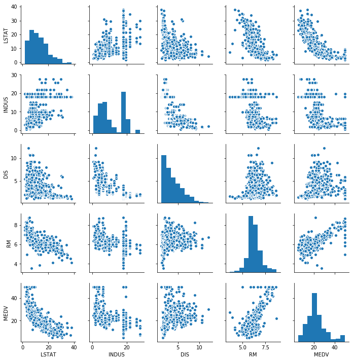

```python
# 散布図行列を出力
# locメソッドで一部の特徴量だけをピックアップ
import seaborn as sns
sns.pairplot(df_pickup, size=2.0)
plt.show()
```

ご覧になっておわかりかと思いますが､散布図行列とは**複数の変数の組み合わせに対して､散布図とヒストグラムを出力したグラフ**のことです｡右下がりの対角線上にヒストグラムが並び､それ以外の場所には対応する2変数についての散布図が出力されています｡これによって､それぞれの変数の分布と､複数の変数同士の関係性をひと目で把握することができます｡重要なのは､**データに表れているパターンから現実の様子を読み取ろうとする姿勢**です｡できるだけ多く､ありそうな仮説を立ててみましょう｡

#### ヒストグラム

ヒストグラムからは､**それぞれの変数がどのように分布しているのか**を知ることができます｡ヒストグラムは多くの場合､左に示す**正規分布**という**釣鐘型**の分布をしています｡平均に最も多くのサンプルが集まって､そこから離れるに連れて数が減っていきます｡**出力されたヒストグラムがこの正規分布からずれていた場合､それなりの理由があることが考えられます**｡

[figure not shown]

たとえば今回ですと､**INDUSのヒストグラムが二山型になっている**ことが特徴的です｡INDUSは小売業以外の商業利用割合､つまりは多くが工業地帯の割合となっています｡それが二山のヒストグラムを作っているということは､**左の山は通常の居住宅区域､右の山が工業地帯を表している**ということが考えられます｡

#### 散布図

散布図からは､**各変数同士がどのような関係性にあるのか**を知ることができます｡今回も**線形モデル**での回帰を行うため､**各説明変数と目的変数MEDVとの直線的な関係性の強さを**評価していくことになります｡

[figure not shown]

現状で言えば､直線的な関係性が強いのは**LSTAT**と**RM**であるように思われます｡また､LSTATとMEDVの関係は曲線的であるようにも見えますが､曲線による回帰は次章の多項式回帰で解説します｡

### 相関係数行列の観察

散布図行列を観察したところで､次に**相関係数行列**を観察してみましょう｡相関係数についても､散布図行列のように多変数の組み合わせに対応する相関係数が出力されます｡直線的な関係性があった**LSTAT**と**RM**について､**目的変数であるMEDVと相関係数**を観察します｡

しかし､実は相関係数行列を数値だけで観察しようとすると､とても見づらいです｡たくさんの数値の羅列になってしまい､見ていると目が疲れてしまいます｡

```python
# 相関係数行列を出力
# 数値の羅列になるので見づらい
df.corr()
```

|  | CRIM | ZN | INDUS | CHAS | NOX | RM | AGE | DIS | RAD | TAX | PTRATIO | B | LSTAT | MEDV |
| --- | --- | --- | --- | --- | --- | --- | --- | --- | --- | --- | --- | --- | --- | --- |
| CRIM | 1.000000 | -0.199458 | 0.404471 | -0.055295 | 0.417521 | -0.219940 | 0.350784 | -0.377904 | 0.622029 | 0.579564 | 0.288250 | -0.377365 | 0.452220 | -0.385832 |
| ZN | -0.199458 | 1.000000 | -0.533828 | -0.042697 | -0.516604 | 0.311991 | -0.569537 | 0.664408 | -0.311948 | -0.314563 | -0.391679 | 0.175520 | -0.412995 | 0.360445 |
| INDUS | 0.404471 | -0.533828 | 1.000000 | 0.062938 | 0.763651 | -0.391676 | 0.644779 | -0.708027 | 0.595129 | 0.720760 | 0.383248 | -0.356977 | 0.603800 | -0.483725 |
| CHAS | -0.055295 | -0.042697 | 0.062938 | 1.000000 | 0.091203 | 0.091251 | 0.086518 | -0.099176 | -0.007368 | -0.035587 | -0.121515 | 0.048788 | -0.053929 | 0.175260 |
| NOX | 0.417521 | -0.516604 | 0.763651 | 0.091203 | 1.000000 | -0.302188 | 0.731470 | -0.769230 | 0.611441 | 0.668023 | 0.188933 | -0.380051 | 0.590879 | -0.427321 |
| RM | -0.219940 | 0.311991 | -0.391676 | 0.091251 | -0.302188 | 1.000000 | -0.240265 | 0.205246 | -0.209847 | -0.292048 | -0.355501 | 0.128069 | -0.613808 | 0.695360 |
| AGE | 0.350784 | -0.569537 | 0.644779 | 0.086518 | 0.731470 | -0.240265 | 1.000000 | -0.747881 | 0.456022 | 0.506456 | 0.261515 | -0.273534 | 0.602339 | -0.376955 |
| DIS | -0.377904 | 0.664408 | -0.708027 | -0.099176 | -0.769230 | 0.205246 | -0.747881 | 1.000000 | -0.494588 | -0.534432 | -0.232471 | 0.291512 | -0.496996 | 0.249929 |
| RAD | 0.622029 | -0.311948 | 0.595129 | -0.007368 | 0.611441 | -0.209847 | 0.456022 | -0.494588 | 1.000000 | 0.910228 | 0.464741 | -0.444413 | 0.488676 | -0.381626 |
| TAX | 0.579564 | -0.314563 | 0.720760 | -0.035587 | 0.668023 | -0.292048 | 0.506456 | -0.534432 | 0.910228 | 1.000000 | 0.460853 | -0.441808 | 0.543993 | -0.468536 |
| PTRATIO | 0.288250 | -0.391679 | 0.383248 | -0.121515 | 0.188933 | -0.355501 | 0.261515 | -0.232471 | 0.464741 | 0.460853 | 1.000000 | -0.177383 | 0.374044 | -0.507787 |
| B | -0.377365 | 0.175520 | -0.356977 | 0.048788 | -0.380051 | 0.128069 | -0.273534 | 0.291512 | -0.444413 | -0.441808 | -0.177383 | 1.000000 | -0.366087 | 0.333461 |
| LSTAT | 0.452220 | -0.412995 | 0.603800 | -0.053929 | 0.590879 | -0.613808 | 0.602339 | -0.496996 | 0.488676 | 0.543993 | 0.374044 | -0.366087 | 1.000000 | -0.737663 |
| MEDV | -0.385832 | 0.360445 | -0.483725 | 0.175260 | -0.427321 | 0.695360 | -0.376955 | 0.249929 | -0.381626 | -0.468536 | -0.507787 | 0.333461 | -0.737663 | 1.000000 |

#### ヒートマップ

[figure not shown]

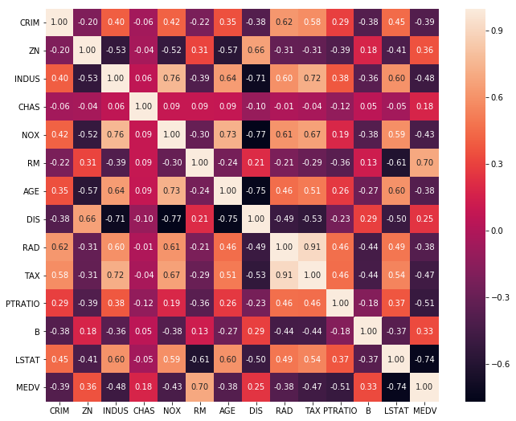

```python
# ヒートマップの表示
plt.figure(figsize=(12, 9))
# annot : 数値を表示するかどうか(annotation)
# square: 四角を正方形に合わせるかどうか
# fmt   : 表示する数値の形式(formatting)
sns.heatmap(df.corr(), annot=True, square=True, fmt='.2f')
plt.show()
```

相関係数を見ても､やはり**LSTAT**はと**RM**直線的な関係が強いことがわかります｡今回は､これら2つの変数を利用して重回帰分析を実行してみます｡

### 基本統計量

また､必要に応じて**基本統計量**を出力することもできます｡pandasの**describe()**関数で出力でき､その際に表示される名称との対応を表にしましたので､参考にしてください｡また､基本統計量に関する詳しい解説は､**基礎統計講座**をご覧ください｡

| 名称 | 説明 |
| --- | --- |
| **count** | サンプル数 |
| **mean** | 平均値 |
| **std** | 標準偏差 |
| **min** | 最小値 |
| **25%** | 第一四分位点 |
| **50%** | 中央値 |
| **75%** | 第三四分位点 |
| **max** | 最大値 |

```python
# 基本統計量を出力
df.describe()
```

|  | CRIM | ZN | INDUS | CHAS | NOX | RM | AGE | DIS | RAD | TAX | PTRATIO | B | LSTAT | MEDV |
| --- | --- | --- | --- | --- | --- | --- | --- | --- | --- | --- | --- | --- | --- | --- |
| count | 506.000000 | 506.000000 | 506.000000 | 506.000000 | 506.000000 | 506.000000 | 506.000000 | 506.000000 | 506.000000 | 506.000000 | 506.000000 | 506.000000 | 506.000000 | 506.000000 |
| mean | 3.593761 | 11.363636 | 11.136779 | 0.069170 | 0.554695 | 6.284634 | 68.574901 | 3.795043 | 9.549407 | 408.237154 | 18.455534 | 356.674032 | 12.653063 | 22.532806 |
| std | 8.596783 | 23.322453 | 6.860353 | 0.253994 | 0.115878 | 0.702617 | 28.148861 | 2.105710 | 8.707259 | 168.537116 | 2.164946 | 91.294864 | 7.141062 | 9.197104 |
| min | 0.006320 | 0.000000 | 0.460000 | 0.000000 | 0.385000 | 3.561000 | 2.900000 | 1.129600 | 1.000000 | 187.000000 | 12.600000 | 0.320000 | 1.730000 | 5.000000 |
| 25% | 0.082045 | 0.000000 | 5.190000 | 0.000000 | 0.449000 | 5.885500 | 45.025000 | 2.100175 | 4.000000 | 279.000000 | 17.400000 | 375.377500 | 6.950000 | 17.025000 |
| 50% | 0.256510 | 0.000000 | 9.690000 | 0.000000 | 0.538000 | 6.208500 | 77.500000 | 3.207450 | 5.000000 | 330.000000 | 19.050000 | 391.440000 | 11.360000 | 21.200000 |
| 75% | 3.647423 | 12.500000 | 18.100000 | 0.000000 | 0.624000 | 6.623500 | 94.075000 | 5.188425 | 24.000000 | 666.000000 | 20.200000 | 396.225000 | 16.955000 | 25.000000 |
| max | 88.976200 | 100.000000 | 27.740000 | 1.000000 | 0.871000 | 8.780000 | 100.000000 | 12.126500 | 24.000000 | 711.000000 | 22.000000 | 396.900000 | 37.970000 | 50.000000 |

## 3.3 前処理

さて､データの観察によって分析の方針が固まってきました｡これから学習のステップに移りたいのですが､その前にしなければならない処理がひとつあります｡それが､**データの分割**です**（本来なら､単回帰分析のときでもすべきですが､説明する文量の関係､でこちらに回しました）**｡こちらは､**過学習**という問題に対処するために行われます｡

### 過学習

過学習とは､**学習データには詳しくなったけど､将来のデータに対してはそれほどでもない**というようなモデルの状態のことを指していいます｡この状態は､たとえるなら**大学受験で高得点を取るために､教科書の問題だけを丸暗記してしまった受験生**に似ています｡受験生は､大学受験を突破するために意味のある知識や思考を身に着けなければならず､教科書の問題と答えを丸暗記しても試験問題は解けません｡

[figure not shown]

それと同じように､機械学習でも**学習データから再現性のない些末なパターンを学習してしまい､将来得られる初見のサンプルに対しての正確な予測ができなくなってしまうのです**｡本来､教師あり学習は**将来の予測を正確に行うことを目指してモデルを構築する**ので､これでは意味がありません｡このような状態を**｢汎化性能（将来のサンプルに対する予測精度）が低い｣**といいます｡また､**過学習はデータが少ないときほど起こりやすくなります**｡十分なデータがないと､重要な法則性が浮かび上がってこずに､些末な部分にばかり目が行くようになってしまうのです｡

[figure not shown]

#### ホールド･アウト法

**ホールド・アウト法**とは､**データを訓練用（trainデータ）と検証用（testデータ）の2つに分割して学習させる方法**です｡これによって､ある程度過学習を検出することができます｡訓練用とは**｢学習に利用する｣**という意味で､検証用とは**｢学習には利用せずに､汎化性能を確認するためだけに利用する｣**という意味です｡学習に利用しなければ､**testデータはモデルにとっては初めて見るサンプルになる**ので､将来得られるサンプルと同様に見えるのです｡先程の受験勉強の例で言えば､教科書で勉強している受験生に**定期的に模試を受けさせることに相当します**｡初見の問題を解かせて､受験本番での出来を推し量るのです｡

[figure not shown]

```python
# 説明変数のデータを用意
# DataFrameの.valuesメソッドでarrayに変換できます
X = df.loc[:, ['LSTAT', 'RM']].values
X
```

```
array([[4.98 , 6.575],
       [9.14 , 6.421],
       [4.03 , 7.185],
       ...,
       [5.64 , 6.976],
       [6.48 , 6.794],
       [7.88 , 6.03 ]])
```

```python
# 教師データを用意
# DataFrameの.valuesメソッドでarrayに変換できます
y = df.loc[:, ['MEDV']].values

# どのように入っているか、最初の１０個を表示して確認
y[:10]
```

```
array([[24. ],
       [21.6],
       [34.7],
       [33.4],
       [36.2],
       [28.7],
       [22.9],
       [27.1],
       [16.5],
       [18.9]])
```

```python
# ホールド・アウト法によるデータの分割
# (X, y, テストにどの割合を割くか, 分割のしかたを決める乱数生成器)
# テストデータの割合は、test_size引数に指定することで変更可能です（今回は、train:test = 7:3）
from sklearn.model_selection import train_test_split
X_train, X_test, y_train, y_test = train_test_split(X, y, test_size = 0.3, random_state = 0)
```

#### 分割されたデータを確認

```python
# データ全体のサンプル数を確認
print(X.shape)
print(y.shape)
```

```
(506, 2)
(506, 1)
```

```python
# trainデータのサンプル数を確認
print(X_train.shape)
print(y_train.shape)
```

```
(354, 2)
(354, 1)
```

```python
# testデータのサンプル数を確認
print(X_test.shape)
print(y_test.shape)
```

```
(152, 2)
(152, 1)
```

## 3.4 線形重回帰モデルの学習

[figure not shown]

```python
# 重回帰の線形回帰を実行
from sklearn.linear_model import LinearRegression
lr = LinearRegression()
```

```python
# 重回帰線形モデルの学習
# trainデータのみを用いていることに注意
lr.fit(X_train, y_train)
```

```
LinearRegression(copy_X=True, fit_intercept=True, n_jobs=1, normalize=False)
```

### モデルの解釈

単回帰分析のときと同じように､パラメータの数値から得られたモデルを解釈していきましょう｡

```python
# 定数項を出力
lr.intercept_
```

```
array([-2.53724672])
```

```python
# 偏回帰係数を出力
# [LSTATの係数, RMの係数]
lr.coef_
```

```
array([[-0.6418309 ,  5.27350522]])
```

係数を出力した結果､以下の線形モデルが得られたことがわかりました｡

$$y = -2.54 - 0.642x_1 + 5.27x_2$$

こちらの結果より､このモデルから**｢ボストン市の各区画の住宅価格の中央値は､部屋数が同じであれば肉体労働者の割合が1%増えると0.642千ドル減少し､肉体労働者の割合が同じであれば部屋が1個増えると5.27千ドル上昇する｣**と解釈できます｡

### 分析結果の利用

さて､それでは学習させたモデルを利用して､**物件のお買い得度の評価**をしましょう｡割高度の目安は以下の表を参考にしてください｡

[figure not shown]

> | 割高度 | 意味 |
> | --- | --- |
> | 0.50 | **相場の半額の価格**で販売されている |
> | 0.75 | **相場の3/4の価格**で販売されている |
> | 1.00 | **相場と同じ価格**で販売されている |
> | 1.50 | **相場の1.5倍の価格**で販売されている |
> | 2.00 | **相場の倍額の価格**で販売されている |

```python
# 新しい物件についてLSTATとRMを入力
# ([[LSTAT, RM]])
X_new = np.array([[12, 3]])

# 販売価格を入力
y_prop = 15

# 適正価格を予測
y_pred = lr.predict(X_new)

# 割高度を計算
price_ratio = y_prop / y_pred

# 出力
print('y_prop      : %.2f' % y_prop)
print('y_pred      : %.2f' % y_pred)
print('price_ratio : %.2f' % price_ratio)
```

```
y_prop      : 15.00
y_pred      : 5.58
price_ratio : 2.69
```

## 3.5 モデルの性能評価

続いて､**学習させたモデルがどの程度信頼できるものなのか**を､以下の4つの指標を用いて評価します｡

#### 数値による評価

1. 決定係数
2. RMSE

#### グラフによる評価

1. 残差プロット
2. グラフの出力

### 1. 決定係数 $R^2$

**決定係数**とは､**重回帰モデルの当てはまりの良さを表す指標**です｡score()メソッドで出力できます｡ここで言う**｢当てはまりの良さ｣**とは､**得られた超平面が特徴空間内に存在するデータ点にどれだけ沿ったものになっているか**という指標です｡当てはまりの良さは予測の精度に直結しますので､決定係数をチェックすることで､モデルの予測性能を数値で評価することができます｡通常､ **$0〜1$ の値を取り､$1$ に近いほど当てはまりが良く､$0$ に近いほど当てはまりが悪いということを意味します** (全く当てはまりが良くないと､マイナスの値を取ることもあります)｡

[figure not shown]

#### 定義式

決定係数は､以下のような定義式で表されます｡注目しているのは**｢ばらつき｣**です｡**目的変数のばらつき**には､平面に平行な成分と､平面に垂直な成分がありますが､**それらのうち平面に沿った成分がどれだけあるかに着目します**｡平面に垂直な成分が少ないほど､値が大きくなるようにできています｡

[figure not shown]

#### 評価目安

決定係数の評価は､以下の目安に従って行ってください｡

| 決定係数 | 評価 |
| --- | --- |
| **0.9以上** | 非常に当てはまりが良い |
| **0.7~0.9** | 当てはまりが良い |
| **0.5~0.7** | あまり当てはまりが良くない |
| **0.5未満** | 当てはまりが悪い |

※注意  
単回帰ではこの決定係数をチェックしませんでしたが､それには理由があります｡実は､式の定義上､**単回帰の場合の決定係数は､相関係数の2乗と同じになってしまう**のです｡なので､単回帰を行うときは相関係数をチェックすれば決定係数を見る必要はありません｡

```python
# 決定係数をtrainとtestに分けて出力
# 過学習しているかどうかを確認
print('R^2')
print('train: %.3f' % lr.score(X_train, y_train))
print('test : %.3f' % lr.score(X_test, y_test))
```

```
R^2
train: 0.651
test : 0.607
```

決定係数を見ると､**学習させたモデルはあまり当てはまりが良いとは言えなさそうです**｡何か当てはまりを悪くする原因があったのでしょうか｡調べていく必要がありそうです｡また､testデータの方が若干小さくなっているので､**やや過学習の傾向もありそうです**｡

### 自由度調整済み決定係数

**自由度調整済み決定係数**とは､**決定係数の改良版**です｡実は､決定係数には**予測の役に立たない変数を追加していくと､数値が意味もなく大きくなっていってしまう**という欠点があり､それを改善しています｡scikit-learnには収録されていませんので､簡単に関数を定義しました｡**特別な理由がない限りは､こちらを参考にする方が望ましいです**｡評価の目安は決定係数と同様です｡

```python
# 自由度調整済み決定係数
# (決定係数, trainまたはtestのサンプル数, 利用した特徴量の数)
def adjusted(score, n_sample, n_features):
    adjusted_score = 1 - (1 - score) * ((n_sample - 1) / (n_sample - n_features - 1))
    return adjusted_score
```

```python
# 自由度調整済み決定係数を出力
print('adjusted R^2')
print('train: %3f' % adjusted(lr.score(X_train, y_train), len(y_train), 2))
print('test : %3f' % adjusted(lr.score(X_test, y_test), len(y_test), 2))
```

```
adjusted R^2
train: 0.648955
test : 0.601704
```

今回は自由度調整済み決定係数を見ても､決定係数と同様の結果が得られました｡

### 2. RMSE（Root Mean Square Error: 平均二乗誤差の平方根）

**RMSE**とは､そのモデルについて､**通常､予測が正解からどれだけズレるか**を表した指標です｡RMSEは､基本統計量の**標準偏差**に近いイメージで捉えることができます｡標準偏差がサンプルの平均に対する標準的なズレを表しているのに対して､**RMSEは正解に対する予測の標準的なズレを表しています**｡

#### 定義式

RMSEは､以下の式で表されます｡最小二乗法のときに登場した二乗誤差の平均を取り（MSE）､平方根を取ることで**二乗をキャンセルしています**｡これによって､**｢千ドル$^2$｣単位で表されていた全体的な誤差を｢千ドル｣単位に戻しています**｡

$$MSE = \frac{1}{n} \sum^{n}_{i=0} ( \hat{y}^{(i)}-{y}^{(i)} )^2$$

$$RMSE = \sqrt{MSE}$$

```python
# MSEを出力する関数を読み込む
from sklearn.metrics import mean_squared_error as mse

# RMSEをtrainとtestに分けて出力
# 過学習をしているかどうかを確認
print('RMSE')
print('train: %.3f' % (mse(y_train, lr.predict(X_train)) ** (1/2)))
print('test : %.3f' % (mse(y_test, lr.predict(X_test)) ** (1/2)))
```

```
RMSE
train: 5.439
test : 5.721
```

testのRMSEを見ると､**｢現在のモデルでは､通常､予測は正解から5.721千ドルずれる｣**ということがわかります｡describe()によると､MEDVは平均が22.53､標準偏差が9.197でした｡なので､**現状のRMSEはそれに対してそこまで小さくありません**｡決定係数からも分かった通り､これではモデルの性能がそれほど高いとは言えません｡

```python
# 基本統計量をもう一度確認
df.describe()
```

|  | CRIM | ZN | INDUS | CHAS | NOX | RM | AGE | DIS | RAD | TAX | PTRATIO | B | LSTAT | MEDV |
| --- | --- | --- | --- | --- | --- | --- | --- | --- | --- | --- | --- | --- | --- | --- |
| count | 506.000000 | 506.000000 | 506.000000 | 506.000000 | 506.000000 | 506.000000 | 506.000000 | 506.000000 | 506.000000 | 506.000000 | 506.000000 | 506.000000 | 506.000000 | 506.000000 |
| mean | 3.593761 | 11.363636 | 11.136779 | 0.069170 | 0.554695 | 6.284634 | 68.574901 | 3.795043 | 9.549407 | 408.237154 | 18.455534 | 356.674032 | 12.653063 | 22.532806 |
| std | 8.596783 | 23.322453 | 6.860353 | 0.253994 | 0.115878 | 0.702617 | 28.148861 | 2.105710 | 8.707259 | 168.537116 | 2.164946 | 91.294864 | 7.141062 | 9.197104 |
| min | 0.006320 | 0.000000 | 0.460000 | 0.000000 | 0.385000 | 3.561000 | 2.900000 | 1.129600 | 1.000000 | 187.000000 | 12.600000 | 0.320000 | 1.730000 | 5.000000 |
| 25% | 0.082045 | 0.000000 | 5.190000 | 0.000000 | 0.449000 | 5.885500 | 45.025000 | 2.100175 | 4.000000 | 279.000000 | 17.400000 | 375.377500 | 6.950000 | 17.025000 |
| 50% | 0.256510 | 0.000000 | 9.690000 | 0.000000 | 0.538000 | 6.208500 | 77.500000 | 3.207450 | 5.000000 | 330.000000 | 19.050000 | 391.440000 | 11.360000 | 21.200000 |
| 75% | 3.647423 | 12.500000 | 18.100000 | 0.000000 | 0.624000 | 6.623500 | 94.075000 | 5.188425 | 24.000000 | 666.000000 | 20.200000 | 396.225000 | 16.955000 | 25.000000 |
| max | 88.976200 | 100.000000 | 27.740000 | 1.000000 | 0.871000 | 8.780000 | 100.000000 | 12.126500 | 24.000000 | 711.000000 | 22.000000 | 396.900000 | 37.970000 | 50.000000 |

### 残差プロット（Residuals Plot）

**残差プロット**とは､**予測の外れ方の傾向を視覚的に掴む手法**です｡横軸に予測値､縦軸に残差が取ってあります｡また､残差の情報からモデルの状態を考察することを**残差分析**と言います｡

$$ Residual = \hat{y} - y $$

```python
# 残差プロットを行う関数を定義
def res_plot(y_train, y_train_pred, y_test, y_test_pred):
    # train, testごとに残差を算出
    res_train = y_train_pred - y_train
    res_test  = y_test_pred - y_test

    # train, testごとに(予測値, 残差)をプロット
    plt.figure(figsize=(8, 8))
    plt.scatter(y_train_pred, res_train, color='blue', marker='o', label='train', alpha=0.5)
    plt.scatter(y_test_pred, res_test, color='green', marker='s', label='test', alpha=0.5)

    plt.xlabel('Predicted Values')                  # x軸のラベルを表示
    plt.ylabel('Residuals')                         # y軸のラベルを表示
    plt.legend(loc='upper left')                    # 凡例を左上に表示
    plt.hlines(y=0, xmin=-10, xmax=50, color='red') # 残差0の線を表示
    plt.xlim([-10, 50])                             # 表示する横軸の範囲を指定
    plt.show()
```

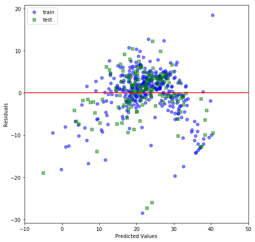

```python
# 残差プロットを出力
res_plot(y_train, lr.predict(X_train), y_test, lr.predict(X_test))
```

#### 前提と着眼点

**残差プロット**は､以下の4つの性質を踏まえると､**残差0の横線を中心に､下図のようにランダムに分布するはずです**｡また､**決定係数が高いほどデータ点が全体的に残差0の横線に近づきます**｡

**残差の性質**

1. 残差の期待値は0
2. 残差どうしは互いに独立
3. 残差は正規分布に従って分布する
4. 残差の分散は等しい

このとき注目すべきは､**外れ値の有無**と**残差の発生傾向**です｡

[figure not shown]

#### 1. 外れ値

**外れ値**とは､**本来ありそうな値から大きく外れた値**のことです｡発生の背景として､何か**特別な理由**があることが多いです｡その他のサンプルと一緒くたにして分析すると､そうした特別な理由が**ノイズ（汲み取るべきでない余計な情報）**となり､モデルが多くのサンプルに当てはまるものにならなくなってしまいます｡**より良いモデルを作ろうとするなら､外れ値はサンプルから取り除くべきです**｡

#### 2. 残差の発生傾向

次に注目すべきは､**残差の発生傾向**です｡**残差の生まれ方に本来ないはずの特殊な傾向が表れているときは､やはりそこにも特別な理由があると考えられます**｡異常値などが原因で適切な回帰式が得られていなかったり､あるいはデータのとり方のクセであったりというノイズが表れていたりということが､例として挙げられます｡

[figure not shown]

#### 平面で観察できる利点

残差プロットは､**多数の変数を用いた重回帰モデルの性質を2次元の平面に落とし込んで観察することが出来ます**｡単回帰のときは､学習させた回帰直線をデータ点に重ねることで観察できましたが､重回帰ではそれが難しくなります｡特に､4次元以上になるとデータの分布の可視化がそもそもできません｡しかし､**残差だけを取り出す残差プロットなら､データの次元に関係なく2次元の平面に落とし込んで観察できます**｡

[figure not shown]

### 2. 回帰平面の可視化

今回は､2つの特徴量を利用していますので､回帰式は目的変数を含めて**3次元の空間内の平面**を表しています｡せっかくなので､**3次元のプロット**でそれを可視化してみましょう｡3次元のプロットは､Seabornと同様に**matplotlibのラッパー**である､**mpl_toolkits**を利用して実行できます｡

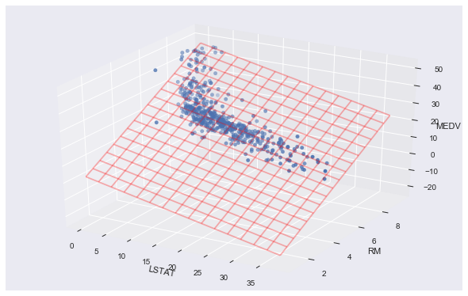

```python
# 3次元のプロットをするためのライブラリを読み込み
from mpl_toolkits.mplot3d import Axes3D

# Axes3Dのインスタンスを生成
ax = Axes3D(plt.figure(figsize=(8, 5)))

# 3次元の散布図を出力
# (x軸, y軸 , z軸)
ax.scatter3D(df['LSTAT'], df['RM'], df['MEDV'])

# # 回帰平面の方程式を定義
X_grid, Y_grid = np.meshgrid(np.arange(0, 40, 2.5), np.arange(1, 10, 0.5))
w0 = lr.intercept_
w1 = lr.coef_[0, 0]
w2 = lr.coef_[0, 1]
Z = w0 + w1*X_grid + w2*Y_grid

# 回帰平面を表示
ax.plot_wireframe(X_grid, Y_grid, Z, alpha=0.3, color='red')

# 座標軸のラベルを指定
ax.set_xlabel('LSTAT')
ax.set_ylabel('RM')
ax.set_zlabel('MEDV')

# ここまでの内容でグラフをプロット
plt.show()
```

## 3.6 標準化重回帰分析

**標準化重回帰分析**とは､**重回帰によって各説明変数の予測における重要性を評価する手法**です｡今までのように**目的変数の構造を定量化する**というよりも､**それぞれの説明変数がどの程度予測の役に立っているのかを定量化する**ことが目的になります｡これを行うと､各偏回帰係数が予測への貢献度を表す数値（**標準偏回帰係数**）に変わります｡

[figure not shown]

### 偏回帰係数の問題点

みなさんは説明変数の重要度を読み取ろうと思ったとき､**｢単純に偏回帰係数を比較すればよさそう｣**とは思いませんでしたか？**偏回帰係数の絶対値が大きいということは､説明変数の変動1あたりの目的変数への影響が大きいことを意味します**｡なので､これは一見よさそうに思えます｡しかし､実はそれはちょっと違います｡

[figure not shown]

ここで注意しなければならないのは､**説明変数の数値1あたりの重みに差がある**ということです｡たとえば､みなさんは**｢1円のお金｣**と**｢1年の時間｣**を同じ価値だと思うでしょうか？恐らく､そうは思わないと思います｡なぜなら､お金は生涯年収で3億円ほど手に入ると言われていますが､時間はせいぜい80年あるかどうかだからです｡**3億あるうちの1なのか､それとも80しかないうちの1なのかでは､変動1あたりの重みが変わってきます**｡通常､重回帰分析に用いる説明変数も**単位がバラバラ**なので､こういったスケーリングの問題が起こります｡**これを解消することができれば､回帰係数に各説明変数の重要性だけを表すようにできます**｡

[figure not shown]

### 標準化

標準化とは､**変数を標準正規分布のスケーリングに合わせる処理**のことです｡一般に､データの分布は何かしらの平均値近くに集まっていて､そこから離れていくにつれて数が減っていくような釣鐘型の**正規分布**をなすとされています｡このときに､**中心位置を表す平均を0に､ばらつきを表す標準偏差を1に統一**させることによって､変数のスケールに合わせます｡こうすれば､偏回帰係数が説明変数の重要度だけを表す**標準化偏回帰係数**になります｡また､その変換は以下の式で実行されます｡

$$z_i = \frac{x_i - \mu}{\sigma}$$

$$x_i: 元データ, \mu: 平均, \sigma: 標準偏差$$

[figure not shown]

変数の標準化は､sklearn.preprocessingに収録されている**StandardScaler**クラスを用いて行うことができます｡**fit_transform()関数**で実行されます｡

```python
# 変数の標準化を実行
from sklearn.preprocessing import StandardScaler
ss = StandardScaler()
X_std = ss.fit_transform(boston.data) # すべての説明変数を変換
y_std = ss.fit_transform(y)
```

#### 標準化された変数の確認

標準化された変数を確認します｡

```python
# 標準化された説明変数を確認
X_std[:5]
```

```
array([[-0.41771335,  0.28482986, -1.2879095 , -0.27259857, -0.14421743,
         0.41367189, -0.12001342,  0.1402136 , -0.98284286, -0.66660821,
        -1.45900038,  0.44105193, -1.0755623 ],
       [-0.41526932, -0.48772236, -0.59338101, -0.27259857, -0.74026221,
         0.19427445,  0.36716642,  0.55715988, -0.8678825 , -0.98732948,
        -0.30309415,  0.44105193, -0.49243937],
       [-0.41527165, -0.48772236, -0.59338101, -0.27259857, -0.74026221,
         1.28271368, -0.26581176,  0.55715988, -0.8678825 , -0.98732948,
        -0.30309415,  0.39642699, -1.2087274 ],
       [-0.41468015, -0.48772236, -1.30687771, -0.27259857, -0.83528384,
         1.01630251, -0.80988851,  1.07773662, -0.75292215, -1.10611514,
         0.1130321 ,  0.41616284, -1.36151682],
       [-0.41040922, -0.48772236, -1.30687771, -0.27259857, -0.83528384,
         1.22857665, -0.51117971,  1.07773662, -0.75292215, -1.10611514,
         0.1130321 ,  0.44105193, -1.02650148]])
```

```python
# 標準化された目的変数を確認
y_std[:10]
```

```
array([[ 0.15968566],
       [-0.10152429],
       [ 1.32424667],
       [ 1.18275795],
       [ 1.48750288],
       [ 0.6712218 ],
       [ 0.03996443],
       [ 0.49708184],
       [-0.65659542],
       [-0.39538548]])
```

#### 平均の確認

**平均が0になっていることを確認しましょう**｡このとき注意してほしいのですが､**コンピュータの仕組みの都合上､数値が正確には0にはなっていません**｡しかし､e-15 ( $10^{-15}$ ) が付いていることからもわかる通り､**限りなく0に近い数値**になっているのがわかるかと思います｡

```python
# 標準化した説明変数の平均を確認
# arrayのmean()メソッドで出力できる
X_std.mean()
```

```
-1.1233877245218975e-15
```

```python
# 標準化した目的変数の平均を確認
# arrayのmean()メソッドで出力できる
y_std.mean()
```

```
-5.1956682259137756e-16
```

#### 標準偏差の確認

続いて､**標準偏差が1になっていることを確認しましょう**｡こちらも､限りなく1に近い数値になります｡

```python
# 標準化した説明変数の標準偏差を確認
# arrayのstd()メソッドで出力できる
X_std.std()
```

```
0.99999999999999944
```

```python
# 標準化した目的変数の標準偏差を確認
# arrayのmean()メソッドで出力できる
y_std.std()
```

```
0.99999999999999989
```

#### 学習

それでは､標準化させた変数を用いて学習を行います｡

```python
# 標準化したデータで線形モデルを学習させる
lr_std = LinearRegression()
lr_std.fit(X_std, y_std)
```

```
LinearRegression(copy_X=True, fit_intercept=True, n_jobs=1, normalize=False)
```

#### 標準化偏回帰係数の比較

標準化偏回帰係数を比較します｡それぞれの変数について､**予測における重要度**が算出されました｡

```python
# 標準偏回帰係数を出力
lr_std.coef_
```

```
array([[-0.10017523,  0.1176512 ,  0.01556018,  0.0742493 , -0.22421527,
         0.29066587,  0.00229872, -0.3378803 ,  0.28937562, -0.22593552,
        -0.22443985,  0.09323458, -0.40799686]])
```

ここで導かれた標準偏回帰係数を絶対値が大きい順､つまりは**重要度が高いと思われる順**に並べました｡

[output not shown]

係数を比較すると､**LSTATは重要度が一番大きい**ということがわかります｡しかし､次に大きいのはRMではなく**DIS（都心からのアクセスの良さ）**でした｡**DIS**は**相関係数が0.25しかないのにもかかわらず､重要度が高いと判断されています**｡これは､一体なぜなのでしょうか？さて､その点も含めて､**重回帰における注意点**を確認していきましょう｡

## 3.7 重回帰分析における注意点

重回帰分析について､注意点を3つほどピックアップしました｡単回帰のときにはなかった､**説明変数を複数利用するからこその注意点**になっています｡こちらを留意の上､分析を行うようにしてください｡

### 抑制変数

抑制変数とは､**目的変数との相関が小さくても予測における重要度が大きい説明変数**のことです｡今回でいえば､**DIS**がそれに該当します｡実は､重回帰においては相関係数というものは重要度を判断するためのひとつの目安に過ぎず､**相関係数だけでは重要度を取りこぼすこともあるのです**｡抑制変数の疑いがある変数が見つかったときは､その変数を利用した学習もさせてみて､**自由度調整済み決定係数がより大きいモデルを採用するようにしましょう**｡

[figure not shown]

### 多重共線性

**多重共線性(multicollinearity)**とは､**相関が強い説明変数同士を一緒に利用したために､回帰式が信頼できないものになってしまうこと**をいいます｡たとえば､今回の予測を**互いに相関が強い2つの変数**を用いて予測すると､以下の図のようになります｡2つの説明変数は相関関係が強いので､**データ点は一本の直線上にまとまるように配置されることになります**｡すると､ここに置かれる平面が不安定になります｡**直線の上に平面を乗せるので､平面がくるくると回転するようになってしまうのです**｡これでは､定まった平面が本当にあるべきものになっているのかどうかが疑わしくなります｡

[figure not shown]

### 交互作用

交互作用とは､**とある説明変数の効果が､別の説明変数の値によって変化する作用のこと**です｡たとえば､とある病気に対する薬の効果が目的変数だったときに､**薬の種類のよっては大人にはよく効くけど､子どもにはむしろ悪影響がある**ということが挙げられます｡**｢どの薬を飲むか｣**という変数と､**｢飲む人が大人か子どもか｣**という変数が互いに影響しているのです｡

[figure not shown]

重回帰で扱う**線形モデル**は､**構造上､交互作用を表現することができません**｡言い方を変えれば､**交互作用が存在しないという仮定のもとで予測を行っているのです**｡交互作用を考慮に含めるためには､この式の構造を変化させる必要があります｡

[figure not shown]

[figure not shown]

監修: 東京女子大学情報処理センター 浅川伸一